# Customer Status Prediction Project

Omar Mohamed Elerakky

Munther Moufeed Abdelrahman

Hamdo Alhassan

2025-12-08

# Project Overview

This project focuses on constructing an **integrated analytical dataset** derived from various customer-related data sources. The objective is to predict customer status (`Onboarding`, `Churn`, `Retained`) using robust classification techniques.

Our dataset provides a **multidimensional view** of behavior, integrating **heterogeneous data** from: * **Demographics** (Age) * **Financials** (MRR, Revenue) * **Support** (Tickets, Bugs) * **Engagement** (Newsletters, Surveys)

By modeling these components, we aim to gain deep insights into customer behavior and develop a predictive system for retention.

# 1 Data Exploration and Visualization

## 1.1 Data Loading & Integration

We load and integrate the 9 different CSV files provided.

**Rationale:** Our data represents a 360-degree view of the customer. It comes from disparate systems: * **CRM**: Demographics, Status * **Finance**: MRR, Revenue * **Support**: Ticket counts, Bug reports * **Marketing**: Newsletter engagement * **Feedback**: Satisfaction surveys

```r
# Define file paths (assuming current working directory)
# Common function to read CSV
read_data <- function(filename) {
  read_csv(filename, show_col_types = FALSE)
}

# Load Train Data
demographics_train <- read_data("customer_demographics_train.csv")
mrr_train <- read_data("customer_monthly_recurring_revenue_train.csv")
region_train <- read_data("customer_region_and_industry_train.csv")
revenue_train <- read_data("customer_revenue_history_train.csv")
satisfaction_train <- read_data("customer_satisfaction_scores_train.csv")
status_train <- read_data("customer_status_level_train.csv") # TARGET
newsletter_train <- read_data("newsletter_engagement_train.csv")
bugs_train <- read_data("product_bug_reports_train.csv")
support_train <- read_data("support_ticket_activity_train.csv")
```

## 1.2 Standardizing & Merging

We standardizing keys and merging into a master training dataframe.

**Technical Detail:** One dataset used `CUS ID` while others used `Customer ID`. Standardizing this primary key is essential for a successful merge. We use a full outer join strategy to ensure no customer data is lost, even if it’s missing from some source files.

```r
# Rename CUS ID
demographics_train <- demographics_train %>% rename(`Customer ID` = `CUS ID`)

# List of dataframes to merge
list_dfs <- list(
  status_train, demographics_train, mrr_train, region_train,
  revenue_train, satisfaction_train, newsletter_train,
  bugs_train, support_train
)

# Merge all into one master dataframe
df_train <- list_dfs %>% reduce(full_join, by = "Customer ID")

cat("Merged Dataset Dimensions:", dim(df_train)[1], "rows and", dim(df_train)[2], "columns.\n")
```

```
## Merged Dataset Dimensions: 8265 rows and 23 columns.
```

## 1.3 Data Cleaning & Preprocessing (Initial)

Parsing dates and cleaning currency text.

**Data Quality Step:** Real-world data is often “dirty”. * **Currency**: Fields like MRR contained symbols (‘$’) and commas, which prevents numerical analysis. We strip these to create valid numbers. * **Dates**: Adjusted to proper date objects to allow for time-based feature engineering later (like calculating account tenure).

```r
# Clean Currency Columns
clean_currency <- function(x) {
  as.numeric(gsub("[$,]", "", x))
}

df_train$`Survey Date` <- ymd(df_train$`Survey Date`)
df_train$`Response Date` <- ymd(df_train$`Response Date`)
df_train$MRR <- clean_currency(df_train$MRR)
df_train$`Total Revenue` <- clean_currency(df_train$`Total Revenue`)
```

## 1.4 Exploratory Data Analysis (EDA)

### 1.4.1 Target Distribution

The balance of the target variable `Status`.

**Insight:** Understanding the class balance is critical. If ‘Churn’ is very rare, we might need special modeling techniques (like oversampling). The chart below shows the proportion of each customer status.

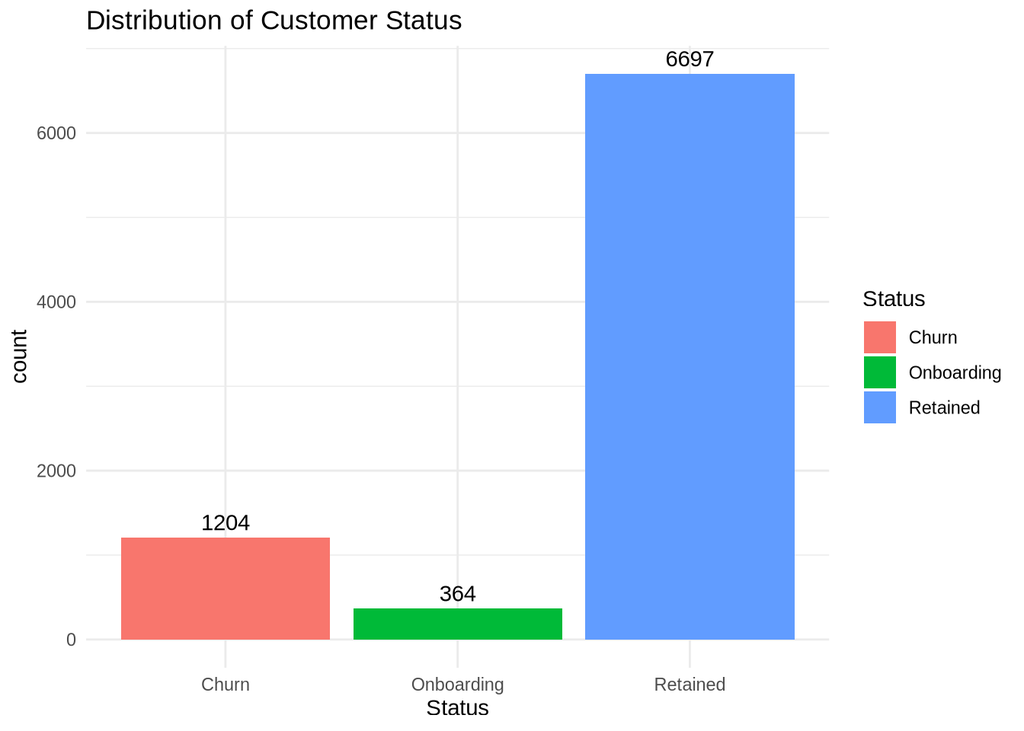

```r
ggplot(df_train, aes(x = Status, fill = Status)) +
  geom_bar() +
  geom_text(stat = "count", aes(label = after_stat(count)), vjust = -0.5) +
  theme_minimal() +
  labs(title = "Distribution of Customer Status")
```

### 1.4.2 Numerical Distributions

Distributions of key metrics.

**Visualization Note:** * **Y-Axis (Count)**: Represents the **number of customers** falling into each category or value range. A higher bar means more customers share that characteristic. * **MRR & Revenue**: These distributions are highly right-skewed (power law). We use a **logarithmic scale** to better visualize the spread of high-value enterprise customers vs. smaller accounts. * **Tenure**: Shows how long customers stay with us.

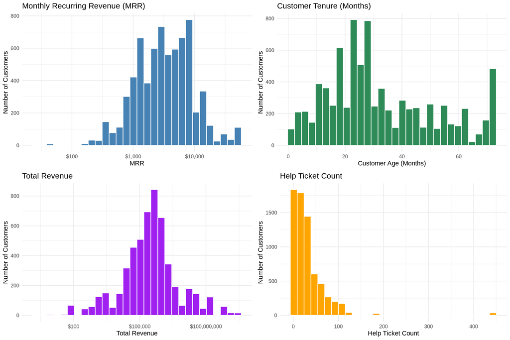

```r
p1 <- ggplot(df_train, aes(x = MRR)) +
  geom_histogram(bins = 30, fill = "steelblue", color = "white") +
  scale_x_log10(labels = scales::dollar) +
  theme_minimal() +
  labs(title = "Monthly Recurring Revenue (MRR)", y = "Number of Customers")

p2 <- ggplot(df_train, aes(x = `Customer Age (Months)`)) +
  geom_histogram(bins = 30, fill = "seagreen", color = "white") +
  theme_minimal() +
  labs(title = "Customer Tenure (Months)", y = "Number of Customers")

# Fixed scientific notation using scale_x_continuous(labels = comma)
p3 <- ggplot(df_train, aes(x = `Total Revenue`)) +
  geom_histogram(bins = 30, fill = "purple", color = "white") +
  scale_x_log10(labels = scales::dollar) +
  theme_minimal() +
  labs(title = "Total Revenue", y = "Number of Customers")

p4 <- ggplot(df_train, aes(x = `Help Ticket Count`)) +
  geom_histogram(bins = 30, fill = "orange", color = "white") +
  theme_minimal() +
  labs(title = "Help Ticket Count", y = "Number of Customers")

grid.arrange(p1, p2, p3, p4, ncol = 2)
```

### 1.4.3 Status vs Metrics

Investigating how metrics differ across status groups.

**Key Driver Analysis:** We look for differences in distributions. * Do ‘Churned’ customers have lower MRR? * Are ‘Retained’ customers with us longer (higher Tenure)? Significant differences here imply these variables will be **strong predictors** in our machine learning model.

**How to Read Box Plots:** * **The Box**: Represents the middle 50% of the data (Interquartile Range). The line inside is the **Median**. * **The Whiskers**: Extend to showing the range of the rest of the data. * **Dots**: Individual points beyond the whiskers are **outliers**. * **Interpretation**: If the boxes for ‘Churn’ and ‘Retained’ are at different heights (do not overlap much), the variable is a good separator.

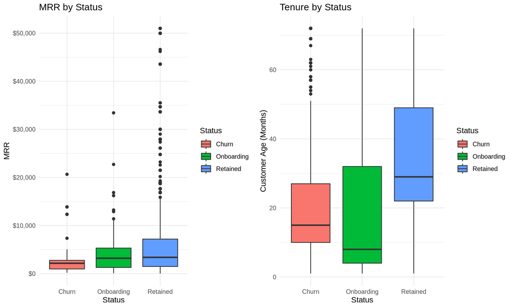

```r
p_mrr <- ggplot(df_train, aes(x = Status, y = MRR, fill = Status)) +
  geom_boxplot() +
  scale_y_continuous(labels = scales::dollar) +
  theme_minimal() +
  labs(title = "MRR by Status")

p_tenure <- ggplot(df_train, aes(x = Status, y = `Customer Age (Months)`, fill = Status)) +
  geom_boxplot() +
  theme_minimal() +
  labs(title = "Tenure by Status")

grid.arrange(p_mrr, p_tenure, ncol = 2)
```

### 1.4.4 Correlation Analysis

Correlations between numerical variables.

**Multicollinearity Check:** We check if variables correlate with each other. dark blue indicates strong positive correlation, red indicates negative. * High correlation between independent variables might mean we can drop one to simplify the model (Dimensionality Reduction).

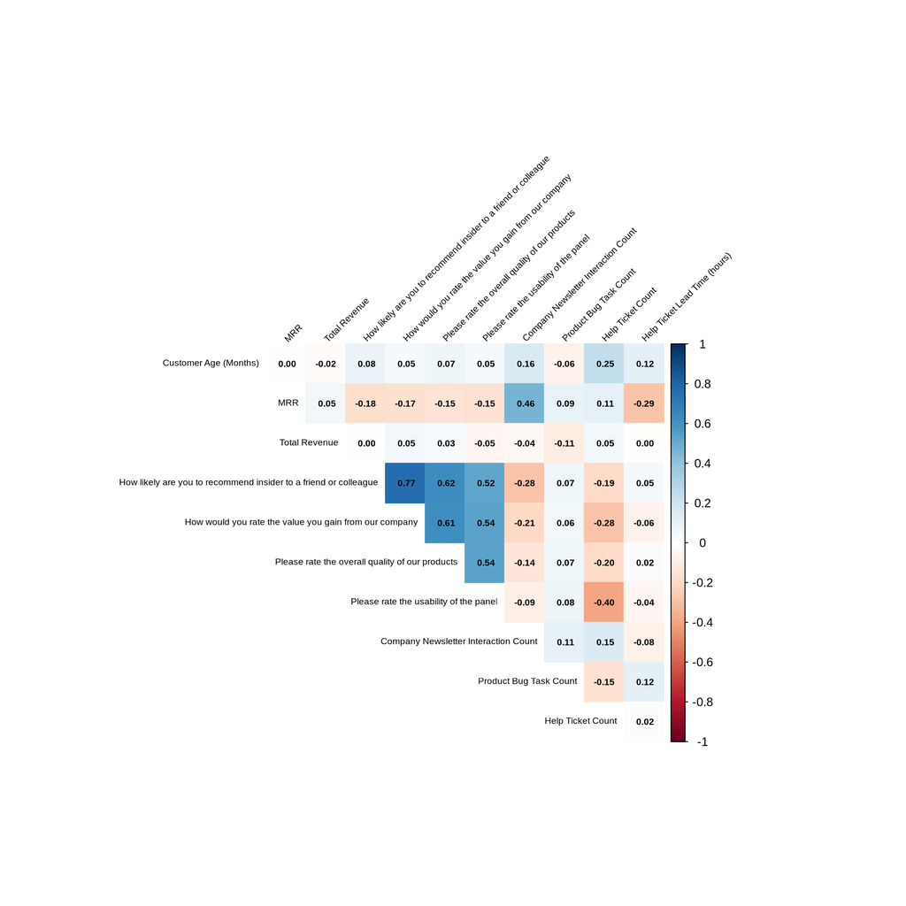

```r
# Select numeric columns and remove ID-like or year columns
nums <- df_train %>%
  select_if(is.numeric) %>%
  select(-c(`Year`, `Quarter`)) %>%
  na.omit() # Remove rows with NAs for correlation

# Compute correlation matrix
M <- cor(nums)

# Plot with adjusted text size (tl.cex) to fix "text margin" error
corrplot(M,
  method = "color", type = "upper",
  tl.col = "black", tl.srt = 45, tl.cex = 0.6,
  addCoef.col = "black", number.cex = 0.6,
  diag = FALSE
)
```

**Conclusion of Phase 1:** We have successfully loaded, merged, and explored the data. We observed the class balance and the distributions of key features. The next phase will focus on detailed Feature Engineering and deeper Data Cleaning (imputation) based on these findings.

# 2 Data Cleaning and Preprocessing

## 2.1 Missing Value Analysis

Before modeling, we must handle missing data. Machine learning models generally cannot handle `NA` values.

**Rationale:** Simply deleting rows with missing data (Complete Case Analysis) can lead to bias if the data isn’t missing completely at random. Imputation allows us to retain valuable diverse data points.

```r
# Visualize missingness
missing_counts <- colSums(is.na(df_train))
missing_dist <- data.frame(Column = names(missing_counts), Missing_Count = missing_counts)
missing_dist <- missing_dist[missing_dist$Missing_Count > 0, ]
missing_dist <- missing_dist[order(-missing_dist$Missing_Count), ]
rownames(missing_dist) <- NULL

knitr::kable(missing_dist, caption = "Missing Values Breakdown")
```

Missing Values Breakdown

| Column | Missing_Count |
| --- | --- |
| Company Newsletter Interaction Count | 6460 |
| Total Revenue | 2291 |
| Please rate the usability of the panel | 1782 |
| How frequently are you using our platform | 1575 |
| Year | 1566 |
| Quarter | 1566 |
| Survey Date | 1566 |
| Response Date | 1566 |
| How likely are you to recommend insider to a friend or colleague | 1566 |
| How would you rate the value you gain from our company | 1566 |
| Please rate the overall quality of our products | 1566 |
| Please rate your understanding of our reporting capabilities in the panel | 1566 |
| Product Bug Task Count | 1566 |
| Help Ticket Count | 1380 |
| Help Ticket Lead Time (hours) | 1380 |
| MRR | 1229 |
| Subvertical | 120 |
| Vertical | 54 |
| Customer Level | 1 |
| Region | 1 |

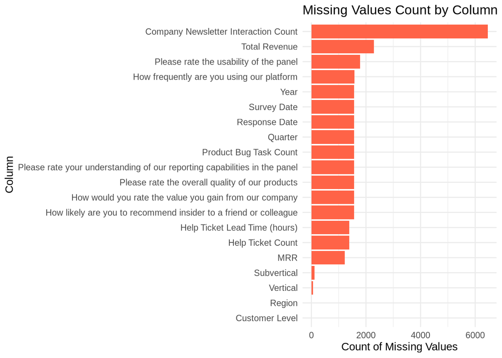

```r
ggplot(missing_dist, aes(x = reorder(Column, Missing_Count), y = Missing_Count)) +
  geom_bar(stat = "identity", fill = "tomato") +
  coord_flip() +
  theme_minimal() +
  labs(title = "Missing Values Count by Column", x = "Column", y = "Count of Missing Values")
```

## 2.2 Imputation Strategy

We will apply specific imputation strategies based on the nature of the column: * **Numerical (e.g., Ticket Count)**: Impute with **0** (assuming NA means no activity) or **Median** (to be robust to outliers). * **Categorical**: Impute with **“Unknown”** to treat missingness as a specific category.

```r
# Define imputation functions
impute_zero <- function(x) replace_na(x, 0)
impute_unknown <- function(x) replace_na(x, "Unknown")
impute_median <- function(x) replace_na(x, median(x, na.rm = TRUE))

df_clean <- df_train

# Impute Zero
df_clean$`Company Newsletter Interaction Count` <- impute_zero(df_clean$`Company Newsletter Interaction Count`)
df_clean$`Product Bug Task Count` <- impute_zero(df_clean$`Product Bug Task Count`)
df_clean$`Help Ticket Count` <- impute_zero(df_clean$`Help Ticket Count`)
df_clean$`Help Ticket Lead Time (hours)` <- impute_zero(df_clean$`Help Ticket Lead Time (hours)`)

# Financials
df_clean$MRR <- impute_zero(df_clean$MRR)
df_clean$`Total Revenue` <- impute_zero(df_clean$`Total Revenue`)

# Impute Median
df_clean$`How likely are you to recommend insider to a friend or colleague` <- impute_median(df_clean$`How likely are you to recommend insider to a friend or colleague`)
df_clean$`Please rate the overall quality of our products` <- impute_median(df_clean$`Please rate the overall quality of our products`)
df_clean$`Please rate the usability of the panel` <- impute_median(df_clean$`Please rate the usability of the panel`)
df_clean$`How would you rate the value you gain from our company` <- impute_median(df_clean$`How would you rate the value you gain from our company`)

# Impute Categorical
df_clean$Region <- impute_unknown(df_clean$Region)
df_clean$Vertical <- impute_unknown(df_clean$Vertical)
df_clean$Subvertical <- impute_unknown(df_clean$Subvertical)
df_clean$`Customer Level` <- impute_unknown(df_clean$`Customer Level`)
df_clean$`How frequently are you using our platform` <- impute_unknown(df_clean$`How frequently are you using our platform`)

# Drop rows missing Target
df_clean <- df_clean[!is.na(df_clean$Status), ]

# Verify no missing values remaining in key columns
sum(is.na(df_clean))
```

```
## [1] 7830
```

## 2.3 Duplicate Removal

Ensuring our dataset contains unique customers.

**Data Consistency:** Duplicate rows would bias the model to over-weigh those specific examples.

```r
# Check for duplicates
original_rows <- nrow(df_clean)
df_clean <- distinct(df_clean)
final_rows <- nrow(df_clean)

cat("Removed", original_rows - final_rows, "duplicate rows.\n")
```

```
## Removed 167 duplicate rows.
```

**Conclusion of Phase 2:** We have produced a clean dataset (`df_clean`) with no missing values in critical columns and no duplicates. This dataset is now ready for Feature Engineering.

# 3 Feature Engineering

## 3.1 Feature Creation

We create new features to capture deeper insights that raw data might miss.

**Rationale:** * **Response Time**: Fast responders might be more engaged (or more angry). * **Normalized Metrics**: `Tickets per Month` compares users fairly regardless of how long they’ve been customers (Tenure).

```r
df_features <- df_clean

# Time-based features
df_features$`Response Time (Days)` <- as.numeric(difftime(df_features$`Response Date`, df_features$`Survey Date`, units = "days"))

# Interaction Ratios (Normalize by Tenure)
tenure_adj <- df_features$`Customer Age (Months)` + 1
df_features$`Tickets Per Month` <- df_features$`Help Ticket Count` / tenure_adj
df_features$`Bugs Per Month` <- df_features$`Product Bug Task Count` / tenure_adj
df_features$`Revenue Per Month` <- df_features$`Total Revenue` / tenure_adj

# Text Length
df_features$`Understanding Score Length` <- str_length(df_features$`Please rate your understanding of our reporting capabilities in the panel`)

# Handle NAs (created if dates were missing)
df_features$`Response Time (Days)` <- replace_na(df_features$`Response Time (Days)`, 0)
df_features$`Understanding Score Length` <- replace_na(df_features$`Understanding Score Length`, 0)

glimpse(df_features)
```

```
## Rows: 8,098
## Columns: 28
## $ `Customer ID`                                                               <chr> …
## $ Status                                                                      <chr> …
## $ `Customer Level`                                                            <chr> …
## $ `Customer Age (Months)`                                                     <dbl> …
## $ MRR                                                                         <dbl> …
## $ Region                                                                      <chr> …
## $ Vertical                                                                    <chr> …
## $ Subvertical                                                                 <chr> …
## $ `Total Revenue`                                                             <dbl> …
## $ Year                                                                        <dbl> …
## $ Quarter                                                                     <dbl> …
## $ `Survey Date`                                                               <date> …
## $ `Response Date`                                                             <date> …
## $ `How likely are you to recommend insider to a friend or colleague`          <dbl> …
## $ `How would you rate the value you gain from our company`                    <dbl> …
## $ `How frequently are you using our platform`                                 <chr> …
## $ `Please rate the overall quality of our products`                           <dbl> …
## $ `Please rate the usability of the panel`                                    <dbl> …
## $ `Please rate your understanding of our reporting capabilities in the panel` <chr> …
## $ `Company Newsletter Interaction Count`                                      <dbl> …
## $ `Product Bug Task Count`                                                    <dbl> …
## $ `Help Ticket Count`                                                         <dbl> …
## $ `Help Ticket Lead Time (hours)`                                             <dbl> …
## $ `Response Time (Days)`                                                      <dbl> …
## $ `Tickets Per Month`                                                         <dbl> …
## $ `Bugs Per Month`                                                            <dbl> …
## $ `Revenue Per Month`                                                         <dbl> …
## $ `Understanding Score Length`                                                <int> …
```

## 3.2 Feature Rationale & Impact

We specifically engineered these features to address bias and capture behavioral trends:

1. **Normalization (X Per Month)**:
   - **Problem**: Raw totals like `Total Revenue` or `Help Ticket Count` are biased by longevity. A customer of 5 years naturally has higher totals than a customer of 1 month, but that doesn’t mean they are “more active”.
   - **Solution**: Dividing by Tenure (`Customer Age`) gives us the **Rate**. A new customer generating $100/month is behaviorally similar to an old customer generating $100/month. This allows the model to compare “apples to apples” regardless of when they joined.
2. **Response Time (Days)**:
   - **Insight**: The delay between receiving a survey and answering it is a proxy for engagement. “Angry” churners often respond immediately to vent, while “Passive” churners might ignore it or delay. This captures that psychological signal.
3. **Understanding Score Length**:
   - **Insight**: The length of text feedback is a behavioral signal. Customers who take the time to write long, detailed responses often have stronger conviction (positive or negative) than those who leave it blank or write one word. This feature quantifies “Effort”.

## 3.3 Categorical Encoding

Preparing text columns for the machine learning model.

**Technical Step:** Models require numerical input. We convert categorical text (Region, Vertical) into “Factors”, which R’s modeling libraries handle automatically (often via dummy encoding behind the scenes).

```r
df_final <- df_features

# Convert to Factors
df_final$Status <- as.factor(df_final$Status)
df_final$Region <- as.factor(df_final$Region)
df_final$Vertical <- as.factor(df_final$Vertical)
# Subvertical has >50 levels, which causes rpart to hang (2^50 splits). We exclude it.
# df_final$Subvertical <- as.factor(df_final$Subvertical)

df_final$`Customer Level` <- as.factor(df_final$`Customer Level`)
df_final$`How frequently are you using our platform` <- as.factor(df_final$`How frequently are you using our platform`)

# Remove identifiers and high-cardinality columns not suitable for trees
df_final$`Customer ID` <- NULL
df_final$Subvertical <- NULL
df_final$`Survey Date` <- NULL
df_final$`Response Date` <- NULL

# Check class balance again on final dataset
summary(df_final$Status)
```

```
##      Churn Onboarding   Retained
##       1194        364       6540
```

# 4 Advanced Analysis

## 4.1 Dimensionality Reduction: PCA

We use **Principal Component Analysis (PCA)** to visualize our multi-dimensional data in 2D space. **Goal**: See if clear patterns emerge between ‘Churn’, ‘Onboarding’, and ‘Retained’ customers before we model them.

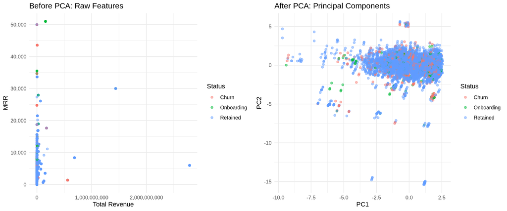

```r
library(cluster)

# 1. Prepare Data (Clean & Scale)
df_clustering <- df_final %>%
  select(where(is.numeric)) %>%
  select(where(~ sd(., na.rm = TRUE) > 0)) %>% # Remove constant columns
  drop_na()

cluster_features <- scale(df_clustering)

# 2. Perform PCA
pca_res <- prcomp(cluster_features, center = TRUE, scale. = TRUE)
df_pca <- as.data.frame(pca_res$x)

# Join Status back for visualization
# Ensure row alignment with the dropped NAs
df_clustering$Status <- df_final$Status[as.numeric(rownames(df_clustering))]
df_pca$Status <- df_clustering$Status

# 3. Visualize
# Before PCA: Visualizing Raw Correlated Features
p_raw <- ggplot(df_clustering, aes(x = `Total Revenue`, y = MRR, color = Status)) +
  geom_point(alpha = 0.5) +
  scale_x_continuous(labels = scales::comma) +
  scale_y_continuous(labels = scales::comma) +
  theme_minimal() +
  labs(title = "Before PCA: Raw Features")

# After PCA: Visualizing Principal Components
p_pca <- ggplot(df_pca, aes(x = PC1, y = PC2, color = Status)) +
  geom_point(alpha = 0.5) +
  theme_minimal() +
  labs(title = "After PCA: Principal Components")

grid.arrange(p_raw, p_pca, ncol = 2)
```

## 4.2 Clustering: k-Means

We use **k-Means Clustering** to discover natural groupings in our customer base, independent of their status tags. This can identify internal personas.

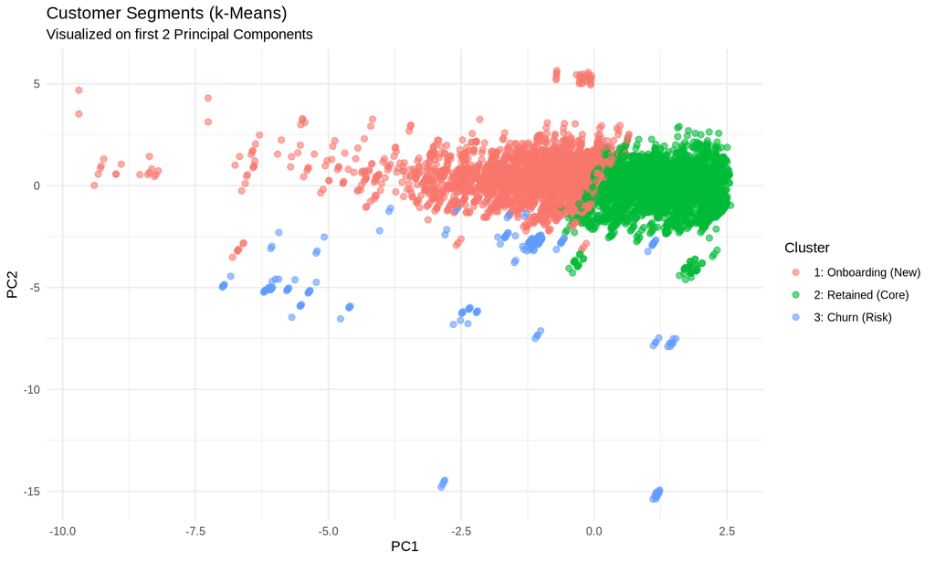

```r
# Reuse the scaled data from PCA step (cluster_features)

# --- Perform k-Means ---
set.seed(123)
kmeans_model <- kmeans(cluster_features, centers = 3, nstart = 25)

# Add cluster labels to PCA data for visualization
df_pca$Cluster <- as.factor(kmeans_model$cluster)

# Visualize Clusters using PCA coordinates
ggplot(df_pca, aes(x = PC1, y = PC2, color = Cluster)) +
  geom_point(alpha = 0.6, size = 2) +
  theme_minimal() +
  scale_color_discrete(labels = c("1: Onboarding (New)", "2: Retained (Core)", "3: Churn (Risk)")) +
  labs(
    title = "Customer Segments (k-Means)",
    subtitle = "Visualized on first 2 Principal Components"
  )
```

# 5 Modeling

## 5.1 Pre-processing: Class Balancing (SMOTE)

Our dataset is imbalanced (fewer ‘Onboarding’ customers). We use **SMOTE (Synthetic Minority Over-sampling Technique)** to generate synthetic examples for the training set.

**Rationale**: Without balancing, models ignore the minority class.

```r
library(smotefamily)
library(caret)
library(rpart)
library(rpart.plot)
library(nnet)

# Prepare Data for SMOTE (Numeric only + Target)
# We need to one-hot encode factors first
# Simple One-Hot Encoding for Model Matrix
df_model_prep <- df_final %>% drop_na()
nums <- df_model_prep %>% select(where(is.numeric))
cats <- df_model_prep %>% select(where(is.factor), -Status)

# Create dummy variables for categorical predictors
# using model.matrix which converts factors to dummies
cats_dummies <- as.data.frame(model.matrix(~ . - 1, data = cats))

# Combine
df_smote_ready <- cbind(nums, cats_dummies, Status = df_model_prep$Status)

# Sanitize names for modeling (rpart doesn't like spaces)
names(df_smote_ready) <- make.names(names(df_smote_ready))

# Split Train/Val (80/20) BEFORE SMOTE
set.seed(123)
train_idx <- sample(seq_len(nrow(df_smote_ready)), size = 0.8 * nrow(df_smote_ready))
train_raw <- df_smote_ready[train_idx, ]
val_set <- df_smote_ready[-train_idx, ]

# Apply SMOTE to TRAINING set only
# SMOTE takes numeric inputs. 'Status' is the target.
# We use smote_family::SMOTE.
# dup_size = 0 means auto-detect amount needed.
smote_result <- SMOTE(
  X = train_raw[, -which(names(train_raw) == "Status")],
  target = train_raw$Status
)

# smotefamily returns a list. $data contains the balanced dataset.
train_balanced <- smote_result$data
# Rename class column back to 'Status' (SMOTE renames it to 'class')
names(train_balanced)[names(train_balanced) == "class"] <- "Status"
train_balanced$Status <- as.factor(train_balanced$Status)

cat("Original Train Size:", nrow(train_raw), "\n")
```

```
## Original Train Size: 5225
```

```r
cat("Balanced Train Size:", nrow(train_balanced), "\n")
```

```
## Balanced Train Size: 10247
```

```r
table(train_balanced$Status)
```

```
##
##      Churn Onboarding   Retained
##        211       5115       4921
```

## 5.2 Model 1: Decision Tree

We train the Decision Tree on the balanced data. This model offers high interpretability by generating explicit “If-Then” rules.

```r
# 1. Train the Model
tree_model <- rpart(Status ~ ., data = train_balanced, method = "class")

# 2. Prune the Tree (for better generalization)
# cp = 0.005 allows the tree to be complex enough to capture 'Churn'
pruned_viz <- prune(tree_model, cp = 0.005)

# 3. Evaluate on Validation Set (Unseen Data)
val_preds_tree <- predict(pruned_viz, newdata = val_set, type = "class")

# 4. Generate Confusion Matrix
cm_tree <- confusionMatrix(val_preds_tree, as.factor(val_set$Status))

# Display Accuracy and Stats
print(cm_tree$overall["Accuracy"])
```

```
##  Accuracy
## 0.9747513
```

```r
print(cm_tree$table)
```

```
##             Reference
## Prediction   Churn Onboarding Retained
##   Churn         15          0        0
##   Onboarding     2         19        2
##   Retained      29          0     1240
```

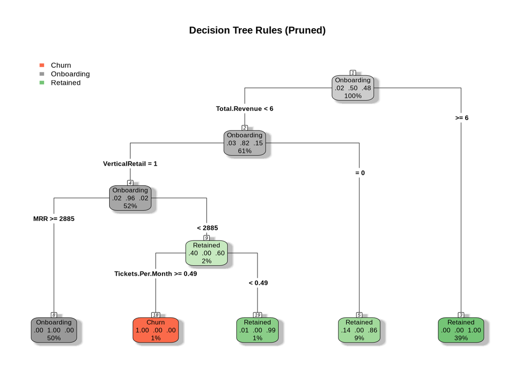

```r
# 5. Visualize Rules
rpart.plot(pruned_viz,
  type = 4,
  extra = 104,
  shadow.col = "gray",
  nn = TRUE,
  main = "Decision Tree Rules (Pruned)"
)
```

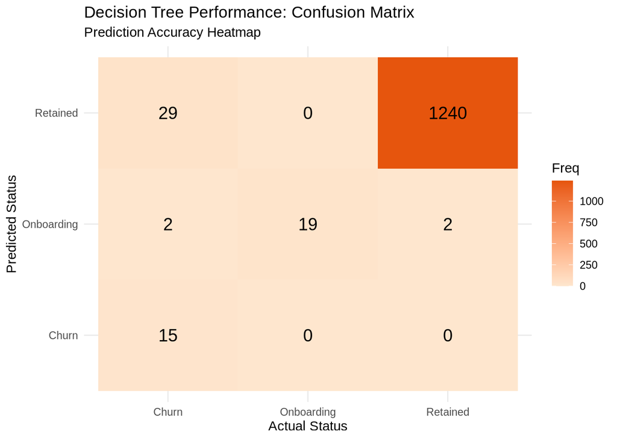

```r
# 6. Visualize Predictions (Confusion Matrix Heatmap)
cm_tree_df <- as.data.frame(cm_tree$table)
ggplot(cm_tree_df, aes(x = Reference, y = Prediction, fill = Freq)) +
  geom_tile() +
  geom_text(aes(label = Freq), color = "black", size = 5) +
  scale_fill_gradient(low = "#fee6ce", high = "#e6550d") + # Orange theme
  labs(
    title = "Decision Tree Performance: Confusion Matrix",
    subtitle = "Prediction Accuracy Heatmap",
    x = "Actual Status",
    y = "Predicted Status"
  ) +
  theme_minimal()
```

## 5.3 Model 2: Multinomial Logistic Regression

We train a linear classifier to compare against the Decision Tree. This model estimates the probability of each status.

```r
# 1. Train the Model
# trace=FALSE hides the iteration log
multi_model <- multinom(Status ~ ., data = train_balanced, trace = FALSE)

# 2. Evaluate on Validation Set (Unseen Data)
# We use the 'val_set' we created before SMOTE to test real-world performance
val_preds <- predict(multi_model, newdata = val_set)

# 3. Generate Confusion Matrix
cm <- confusionMatrix(val_preds, as.factor(val_set$Status))

# Display Accuracy and Stats
print(cm$overall["Accuracy"])
```

```
##  Accuracy
## 0.9877582
```

```r
print(cm$table)
```

```
##             Reference
## Prediction   Churn Onboarding Retained
##   Churn         35          0        5
##   Onboarding     1         19        0
##   Retained      10          0     1237
```

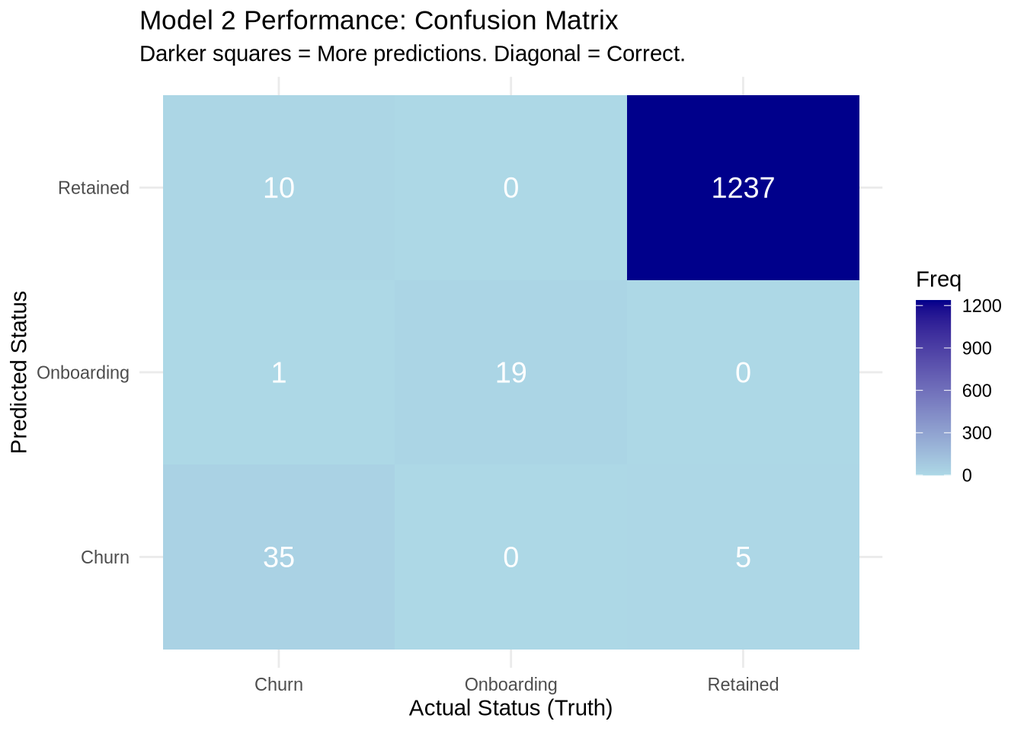

```r
# 4. Visualize Performance (Confusion Matrix Heatmap)
cm_df <- as.data.frame(cm$table)
ggplot(cm_df, aes(x = Reference, y = Prediction, fill = Freq)) +
  geom_tile() +
  geom_text(aes(label = Freq), color = "white", size = 5) +
  scale_fill_gradient(low = "lightblue", high = "darkblue") +
  labs(
    title = "Model 2 Performance: Confusion Matrix",
    subtitle = "Darker squares = More predictions. Diagonal = Correct.",
    x = "Actual Status (Truth)",
    y = "Predicted Status"
  ) +
  theme_minimal()
```

**Model Evaluation:** * **Accuracy**: The model’s accuracy on the validation set is the primary metric. * **Heatmap Interpretation**: * **The Diagonal**: Ideally, all high numbers should be on the diagonal (Predicted = Actual). * **Off-Diagonal**: Any numbers off the diagonal are errors. For example, if we see a high number for `Actual: Churn` but `Predicted: Retained`, that’s a dangerous model failure (ignoring risk).